# Building Autoencoder from Scratch

[figure not shown]

## Implementing Autoencoder!

```python
! pip install -q torch_snippets
```

```
WARNING: Running pip as the 'root' user can result in broken permissions and conflicting behaviour with the system package manager. It is recommended to use a virtual environment instead: https://pip.pypa.io/warnings/venv
```

```python
from torch_snippets import *
from torchvision.datasets import MNIST
from torchvision import transforms
device = 'cuda' if torch.cuda.is_available() else 'cpu'
```

```python
# Specify the transformation that we want our images to pass through:
img_transforms = transforms.Compose([
                 transforms.ToTensor(),
                 transforms.Normalize([0.5], [0.5]),
                 transforms.Lambda(lambda x: x.to(device))
])
```

```python
# pip install ipywidgets
```

```python
# Create train and validation dataset
train_ds = MNIST('content/', transform = img_transforms, train = True, download = True)
valid_ds = MNIST('content/', transform = img_transforms, train = False, download = True)
```

```python
# Define datalaoder
batch_size = 256
train_loader = DataLoader(train_ds, batch_size = batch_size, shuffle = True)
valid_loader = DataLoader(valid_ds, batch_size = batch_size, shuffle = False)
```

Define the network architecture. We define the `AutoEncoder class` constituting the encoder and decoder in the `__init__` method, along with the dimension of the **bottleneck layer**, `latent_dim`, and the `forward method`, and visualize the model summary:

```python
# Define the AutoEncoder class and the __init__ method containing the encoder,
# decoder, and the dimension of the bottleneck layer:

class AutoEncoder(nn.Module):
    def __init__(self, latent_dim):
        super().__init__()
        self.latent_dim = latent_dim
        self.encoder = nn.Sequential(
                            nn.Linear(28*28, 128),
                            nn.ReLU(True),
                            nn.Linear(128, 64),
                            nn.ReLU(True),
                            nn.Linear(64, latent_dim))   # latent_dim --> bottleneck layer remember architecture above
        self.decoder = nn.Sequential(
                            nn.Linear(latent_dim, 64),
                            nn.ReLU(True),
                            nn.Linear(64, 128),
                            nn.ReLU(True),
                            nn.Linear(128, 28*28),
                            nn.Tanh())


    def forward(self, x):
        x = x.view(len(x), -1)
        x = self.encoder(x)
        x = self.decoder(x)
        x = x.view(len(x), 1, 28, 28)
        return x
```

```python
! pip install torch_summary
```

```
WARNING: Running pip as the 'root' user can result in broken permissions and conflicting behaviour with the system package manager. It is recommended to use a virtual environment instead: https://pip.pypa.io/warnings/venv
```

```python
from torchsummary import summary
model = AutoEncoder(3).to(device)
```

```python
summary(model, torch.zeros(2,1,28,28));
```

```
==========================================================================================
Layer (type:depth-idx)                   Output Shape              Param #
==========================================================================================
├─Sequential: 1-1                        [-1, 3]                   --
|    └─Linear: 2-1                       [-1, 128]                 100,480
|    └─ReLU: 2-2                         [-1, 128]                 --
|    └─Linear: 2-3                       [-1, 64]                  8,256
|    └─ReLU: 2-4                         [-1, 64]                  --
|    └─Linear: 2-5                       [-1, 3]                   195
├─Sequential: 1-2                        [-1, 784]                 --
|    └─Linear: 2-6                       [-1, 64]                  256
|    └─ReLU: 2-7                         [-1, 64]                  --
|    └─Linear: 2-8                       [-1, 128]                 8,320
|    └─ReLU: 2-9                         [-1, 128]                 --
|    └─Linear: 2-10                      [-1, 784]                 101,136
|    └─Tanh: 2-11                        [-1, 784]                 --
==========================================================================================
Total params: 218,643
Trainable params: 218,643
Non-trainable params: 0
Total mult-adds (M): 0.43
==========================================================================================
Input size (MB): 0.01
Forward/backward pass size (MB): 0.01
Params size (MB): 0.83
Estimated Total Size (MB): 0.85
==========================================================================================
```

#### From the preceding output, we can see that the Linear: **`2-5 layer`** is the bottleneck layer, where each image is represented as a 3-dimensional vector. Furthermore, the decoder layer reconstructs the original image using the three values in the bottleneck layer.

```python
# Define a function to train on a batch of data (train_batch)
def train_batch(input, model, criterion, optimizer):
    model.train()
    optimizer.zero_grad()
    output = model(input)
    loss = criterion(output, input)
    loss.backward()
    optimizer.step()
    return loss
```

```python
# Define the function to validate on the batch of data (validate_batch):
@torch.no_grad()
def valid_batch(input, model, criterion):
    model.eval()
    output = model(input)
    loss = criterion(output, input)
    return loss
```

```python
import torch
```

```python
# Define the model, loss criterion, and optimizer:
model = AutoEncoder(3).to(device)
criterion = nn.MSELoss()
optimizer = optim.AdamW(model.parameters(), lr = 0.001, weight_decay = 0.00001)
```

```
EPOCH: 1.000	train_loss: 0.262	valid_loss: 0.192	(16.28s - 65.12s remaining)
EPOCH: 2.000	train_loss: 0.177	valid_loss: 0.166	(31.98s - 47.97s remaining)
EPOCH: 3.000	train_loss: 0.160	valid_loss: 0.155	(48.26s - 32.18s remaining)
EPOCH: 4.000	train_loss: 0.153	valid_loss: 0.151	(64.22s - 16.06s remaining)
EPOCH: 5.000	train_loss: 0.149	valid_loss: 0.148	(80.38s - 0.00s remaining)
```

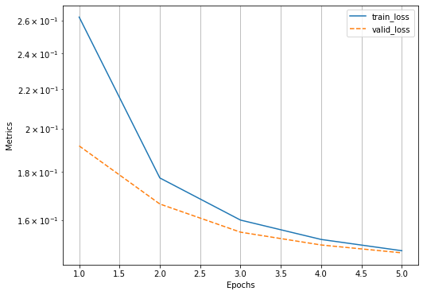

```python
# Train the model over increasing epochs:
num_epochs = 5
log = Report(num_epochs)

for epoch in range(num_epochs):
    N = len(train_loader)
    for idx, (data, _) in enumerate(train_loader):
        loss = train_batch(data, model, criterion, optimizer)
        log.record(pos = (epoch + (idx+1)/N), train_loss = loss, end = '\r')

    # This is for validation
    N = len(valid_loader)
    for idx, (data, _) in enumerate(valid_loader):
        loss = valid_batch(data, model, criterion)
        log.record(pos = (epoch + (idx+1)/N), valid_loss = loss, end = '\r')

    log.report_avgs(epoch+1)
log.plot_epochs(log=True)
```

```python
valid_ds[0]
```

[output not shown]

[output cut: 59 more lines]

[output not shown]

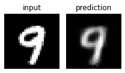

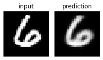

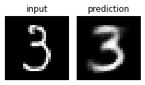

```python
# Validate the model on the val_ds dataset, which was not provided during training:

for _ in range(3):
    idx = np.random.randint(len(valid_ds))
    im, _ = valid_ds[idx]
    _im = model(im[None])[0]
    fig, ax = plt.subplots(1, 2, figsize=(3,3))
    show(im[0], ax = ax[0], title = 'input')
    show(_im[0], ax = ax[1], title = 'prediction')
    plt.tight_layout()
    plt.show()
```

*Conclusion*:

> We can see that the network can reproduce input with a very high level of accuracy even though the bottleneck layer is only three dimensions in size. However, the images are not as clear as we expect them to be. This is primarily because of the small number of nodes in the bottleneck layer. In the following image, we will visualize the reconstructed images after training networks with different bottleneck layer sizes - 2, 3, 5, 10, and 50:

```python
def train_auto_encoder(latent_dim):

    model = AutoEncoder(latent_dim).to(device)
    criterion = nn.MSELoss()
    optimizer = optim.AdamW(model.parameters(), lr = 0.001, weight_decay = 0.00001)

    num_epochs = 5
    log = Report(num_epochs)

    for epoch in range(num_epochs):
        N = len(train_loader)
        for idx, (data, _) in enumerate(train_loader):
            loss = train_batch(data, model, criterion, optimizer)
            log.record(pos = (epoch + (idx+1)/N), train_loss = loss, end = '\r')

        # This is for validation
        N = len(valid_loader)
        for idx, (data, _) in enumerate(valid_loader):
            loss = valid_batch(data, model, criterion)
            log.record(pos = (epoch + (idx+1)/N), valid_loss = loss, end = '\r')

        log.report_avgs(epoch+1)
    log.plot_epochs(log=True)
    return model
```

```
EPOCH: 1.000	train_loss: 0.245	valid_loss: 0.142	(16.24s - 64.98s remaining)
EPOCH: 2.000	train_loss: 0.123	valid_loss: 0.105	(32.17s - 48.25s remaining)
EPOCH: 3.000	train_loss: 0.096	valid_loss: 0.086	(48.57s - 32.38s remaining)
EPOCH: 4.000	train_loss: 0.081	valid_loss: 0.075	(65.23s - 16.31s remaining)
EPOCH: 5.000	train_loss: 0.073	valid_loss: 0.067	(81.65s - 0.00s remaining)
```

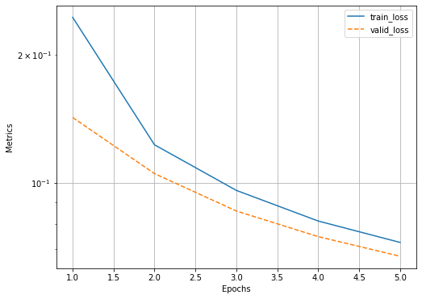

```
EPOCH: 1.000	train_loss: 0.281	valid_loss: 0.223	(16.72s - 66.87s remaining)
EPOCH: 2.000	train_loss: 0.212	valid_loss: 0.202	(32.89s - 49.33s remaining)
EPOCH: 3.000	train_loss: 0.194	valid_loss: 0.190	(49.11s - 32.74s remaining)
EPOCH: 4.000	train_loss: 0.185	valid_loss: 0.182	(65.33s - 16.33s remaining)
EPOCH: 5.000	train_loss: 0.180	valid_loss: 0.178	(81.96s - 0.00s remaining)
```

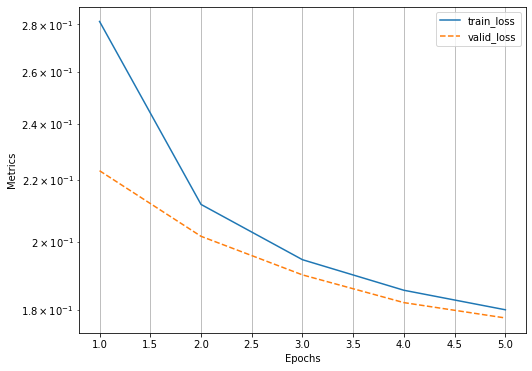

```
EPOCH: 1.000	train_loss: 0.258	valid_loss: 0.196	(16.65s - 66.60s remaining)
EPOCH: 2.000	train_loss: 0.181	valid_loss: 0.171	(33.34s - 50.01s remaining)
EPOCH: 3.000	train_loss: 0.166	valid_loss: 0.160	(50.11s - 33.41s remaining)
EPOCH: 4.000	train_loss: 0.158	valid_loss: 0.154	(67.08s - 16.77s remaining)
EPOCH: 5.000	train_loss: 0.152	valid_loss: 0.149	(84.20s - 0.00s remaining)
```

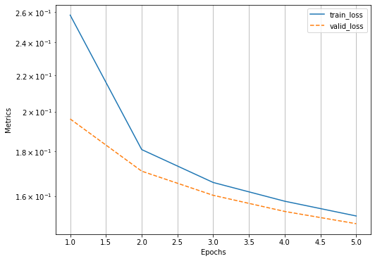

```
EPOCH: 1.000	train_loss: 0.249	valid_loss: 0.166	(17.26s - 69.04s remaining)
EPOCH: 2.000	train_loss: 0.150	valid_loss: 0.138	(34.48s - 51.73s remaining)
EPOCH: 3.000	train_loss: 0.133	valid_loss: 0.128	(51.08s - 34.05s remaining)
EPOCH: 4.000	train_loss: 0.126	valid_loss: 0.123	(67.48s - 16.87s remaining)
EPOCH: 5.000	train_loss: 0.121	valid_loss: 0.119	(83.52s - 0.00s remaining)
```

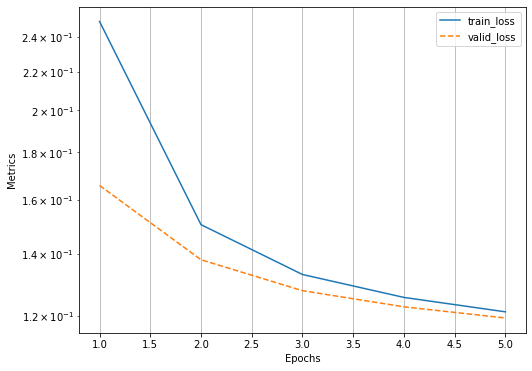

```
EPOCH: 1.000	train_loss: 0.246	valid_loss: 0.146	(16.40s - 65.61s remaining)
EPOCH: 2.000	train_loss: 0.125	valid_loss: 0.108	(33.38s - 50.08s remaining)
EPOCH: 3.000	train_loss: 0.103	valid_loss: 0.096	(50.04s - 33.36s remaining)
EPOCH: 4.000	train_loss: 0.095	valid_loss: 0.091	(66.33s - 16.58s remaining)
EPOCH: 5.000	train_loss: 0.091	valid_loss: 0.087	(82.39s - 0.00s remaining)
```

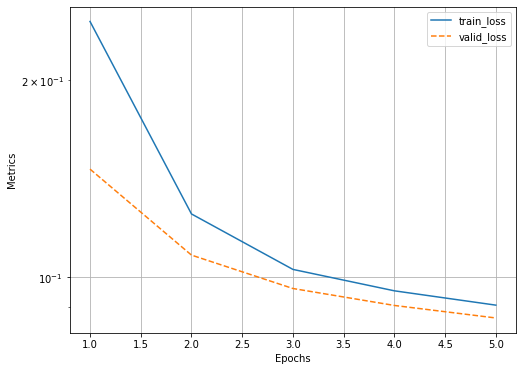

```python
latent_dim = [train_auto_encoder(dim) for dim in [50, 2, 3, 5, 10]]
```

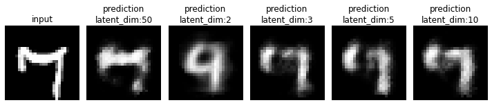

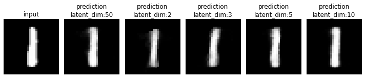

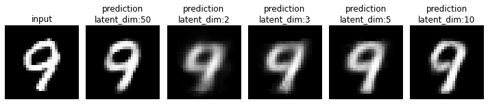

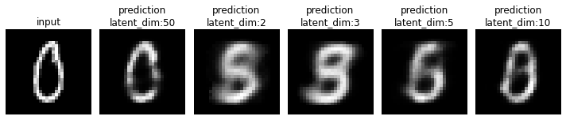

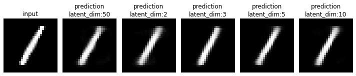

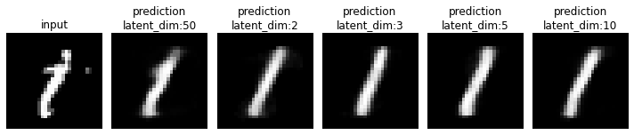

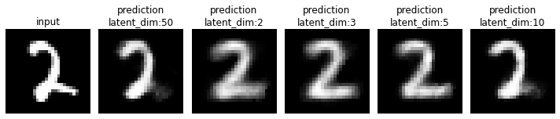

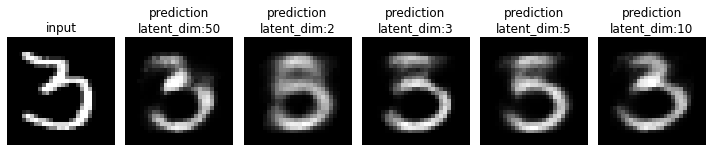

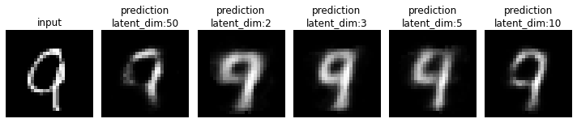

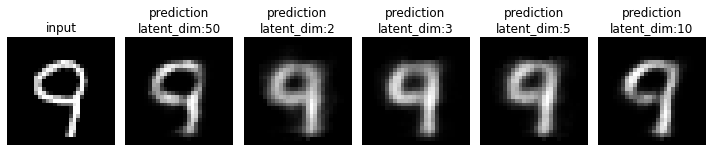

```python
for _ in range(10):
    idx = np.random.randint(len(valid_ds))
    im, _ = valid_ds[idx]
    fig, ax = plt.subplots(1, len(latent_dim) + 1, figsize=(10, 4))
    ax = iter(ax.flat)
    show(im[0], ax=next(ax), title='input')
    for auto_encoder in latent_dim:
        _im = auto_encoder(im[None])[0]
        show(_im[0], ax=next(ax), title=f'prediction\nlatent_dim:{auto_encoder.latent_dim}')
    plt.tight_layout()
    plt.show()
```

*It is clear that as the number of vectors in the bottleneck layer increased, the clarity of the reconstructed image improved.*